# RNA-Seq Differential Expression Analysis Using DESeq2

Shradha Upadhyay

2026-07-22

# Introduction

This project demonstrates differential gene expression analysis of RNA-seq count data using DESeq2 in R. DESeq2 is one of the most widely used Bioconductor packages for identifying differentially expressed genes from RNA sequencing experiments.

# Load Required Libraries

```r
library(DESeq2)
```

## Research Question

**Which genes are differentially expressed between pancreatic islet samples from individuals with Type 2 Diabetes and healthy controls?**

## Dataset

This project uses the publicly available **GSE86468** RNA-seq dataset obtained from the Gene Expression Omnibus (GEO). The dataset contains pancreatic islet samples collected from individuals with Type 2 Diabetes and healthy controls. Gene expression values are provided as **RSEM expected counts**, which are later rounded to integers for demonstration of the DESeq2 workflow.

# Load the Dataset

```r
getwd()
```

```
## [1] "C:/Users/shrup/OneDrive/Desktop/RNASeq-Differential-Expression-DESeq2/notebooks"
```

```r
file.exists("../data/GSE86468_GEO.bulk.islet.processed.data.RSEM.raw.expected.counts.csv.gz")
```

```
## [1] TRUE
```

```r
counts <- read.csv("../data/GSE86468_GEO.bulk.islet.processed.data.RSEM.raw.expected.counts.csv.gz")
```

#The dataset contains RNA-seq expression estimates (RSEM expected counts) from pancreatic islet samples collected from individuals with Type 2 Diabetes and healthy controls. These expression values will be used to identify genes that differ between the two groups.

# Explore the Data

```r
dim(counts)
```

```
## [1] 26616    25
```

The dataset contains 26,616 genes (rows) and 25 columns consisting of gene information and RNA-seq sample counts. > **Note:** This dataset contains **RSEM expected counts** rather than raw integer read counts. RSEM assigns sequencing reads probabilistically when they map to multiple transcripts, resulting in decimal expression estimates. For this educational project, the expected counts are rounded before DESeq2 analysis. In production analyses, raw counts generated by tools such as featureCounts are generally preferred.

```r
colnames(counts)
```

```
##  [1] "X"                                  "baseline.03182015_S2"
##  [3] "baseline.03272015_S8"               "baseline.05202015.Islet.15_S1"
##  [5] "baseline.05222015.Islet.16_S6"      "baseline.09032015_S2"
##  [7] "baseline.09102015_S7"               "baseline.10012015_S12"
##  [9] "baseline.10292015_S17"              "Single.cell.bulk.03182015_S4"
## [11] "Single.cell.bulk.03272015_S10"      "Single.cell.bulk.05202015_S3"
## [13] "Single.cell.bulk.05222015_S8"       "Single.cell.bulk.c1.09032015_S5"
## [15] "Single.cell.bulk.c1.09102015_S10"   "Single.cell.bulk.c1.10012015_S15"
## [17] "Single.cell.bulk.c1.10292015_S20"   "undissociated.c1.ctrl.09032015_S3"
## [19] "undissociated.c1.ctrl.09102015_S8"  "undissociated.c1.ctrl.10012015_S13"
## [21] "undissociated.c1.ctrl.10292015_S18" "Untreated.Ctrl.03182015_S3"
## [23] "Untreated.Ctrl.03272015_S9"         "Untreated.Ctrl.05202015_S2"
## [25] "Untreated.Ctrl.05222015_S7"
```

## View the First Few Rows

The dataset contains **26,616 genes (rows)** and **25 columns**.

- The first column contains Ensembl Gene IDs.
- The remaining 24 columns represent RNA-seq samples.
- Each cell contains an RSEM expected count (estimated expression) for a gene in a sample.

```r
head(counts)
```

```
##                 X baseline.03182015_S2 baseline.03272015_S8
## 1 ENSG00000229483                 0.00                 0.00
## 2 ENSG00000232849                 0.00                 0.00
## 3 ENSG00000229558                 0.00                 0.00
## 4 ENSG00000232977                30.17                24.52
## 5 ENSG00000227893                92.73                69.56
## 6 ENSG00000238230                 0.00                 0.00
##   baseline.05202015.Islet.15_S1 baseline.05222015.Islet.16_S6
## 1                          0.00                          0.00
## 2                          0.00                          0.00
## 3                          1.00                          1.00
## 4                          2.16                         20.48
## 5                         25.70                         40.61
## 6                          1.00                          1.00
##   baseline.09032015_S2 baseline.09102015_S7 baseline.10012015_S12
```

[output cut: 69 more lines]

## Rename the First Column

```r
colnames(counts)[1] <- "Gene_ID"

colnames(counts)[1]
```

```
## [1] "Gene_ID"
```

```r
colnames(counts)
```

```
##  [1] "Gene_ID"                            "baseline.03182015_S2"
##  [3] "baseline.03272015_S8"               "baseline.05202015.Islet.15_S1"
##  [5] "baseline.05222015.Islet.16_S6"      "baseline.09032015_S2"
##  [7] "baseline.09102015_S7"               "baseline.10012015_S12"
##  [9] "baseline.10292015_S17"              "Single.cell.bulk.03182015_S4"
## [11] "Single.cell.bulk.03272015_S10"      "Single.cell.bulk.05202015_S3"
## [13] "Single.cell.bulk.05222015_S8"       "Single.cell.bulk.c1.09032015_S5"
## [15] "Single.cell.bulk.c1.09102015_S10"   "Single.cell.bulk.c1.10012015_S15"
## [17] "Single.cell.bulk.c1.10292015_S20"   "undissociated.c1.ctrl.09032015_S3"
## [19] "undissociated.c1.ctrl.09102015_S8"  "undissociated.c1.ctrl.10012015_S13"
## [21] "undissociated.c1.ctrl.10292015_S18" "Untreated.Ctrl.03182015_S3"
## [23] "Untreated.Ctrl.03272015_S9"         "Untreated.Ctrl.05202015_S2"
## [25] "Untreated.Ctrl.05222015_S7"
```

## Create Sample Metadata (colData)

```r
colData <- data.frame(
  Sample = colnames(counts)[-1],   #colnames(counts)[2:25]

   Condition = c(
    rep("Diabetic", 16),
    rep("Control", 8)
  )
  )
dim(colData)
```

```
## [1] 24  2
```

```r
table(colData$Condition)
```

```
##
##  Control Diabetic
##        8       16
```

```r
# Use sample names as row names
rownames(colData) <- colData$Sample
head(rownames(colData))
```

```
## [1] "baseline.03182015_S2"          "baseline.03272015_S8"
## [3] "baseline.05202015.Islet.15_S1" "baseline.05222015.Islet.16_S6"
## [5] "baseline.09032015_S2"          "baseline.09102015_S7"
```

```r
# Convert the Condition column into a factor
# Control is used as the reference group
colData$Condition <- factor(
  colData$Condition,
  levels = c("Control", "Diabetic")
)
str(colData)
```

```
## 'data.frame':    24 obs. of  2 variables:
##  $ Sample   : chr  "baseline.03182015_S2" "baseline.03272015_S8" "baseline.05202015.Islet.15_S1" "baseline.05222015.Islet.16_S6" ...
##  $ Condition: Factor w/ 2 levels "Control","Diabetic": 2 2 2 2 2 2 2 2 2 2 ...
```

## Prepare the Count Matrix for DESeq2

### Why do we set Gene IDs as row names?

DESeq2 requires the count matrix to contain **only numeric count values** while the **gene identifiers are stored as row names**. This allows DESeq2 to associate each row of expression counts with its corresponding gene during differential expression analysis.

In this step, we move the `Gene_ID` column to the row names and remove it from the count matrix.

```r
# Store Gene_ID as row names
rownames(counts) <- counts$Gene_ID

# Remove the Gene_ID column
count_matrix <- counts[, -1]

# Check the dimensions
dim(count_matrix)
```

```
## [1] 26616    24
```

```r
# View the first six rows
head(count_matrix)
```

```
##                 baseline.03182015_S2 baseline.03272015_S8
## ENSG00000229483                 0.00                 0.00
## ENSG00000232849                 0.00                 0.00
## ENSG00000229558                 0.00                 0.00
## ENSG00000232977                30.17                24.52
## ENSG00000227893                92.73                69.56
## ENSG00000238230                 0.00                 0.00
##                 baseline.05202015.Islet.15_S1 baseline.05222015.Islet.16_S6
## ENSG00000229483                          0.00                          0.00
## ENSG00000232849                          0.00                          0.00
## ENSG00000229558                          1.00                          1.00
## ENSG00000232977                          2.16                         20.48
## ENSG00000227893                         25.70                         40.61
## ENSG00000238230                          1.00                          1.00
##                 baseline.09032015_S2 baseline.09102015_S7 baseline.10012015_S12
## ENSG00000229483                 0.00                 0.00                  0.00
## ENSG00000232849                 0.00                 0.00                  0.00
## ENSG00000229558                 0.00                 0.00                  2.00
## ENSG00000232977                 4.14                 3.26                  9.61
## ENSG00000227893                 8.90                13.44                 39.80
## ENSG00000238230                 0.00                 0.00                  0.00
##                 baseline.10292015_S17 Single.cell.bulk.03182015_S4
## ENSG00000229483                  0.00                         0.00
## ENSG00000232849                  0.00                         0.00
## ENSG00000229558                  1.00                         0.00
## ENSG00000232977                 16.66                        19.63
## ENSG00000227893                 37.41                        77.57
## ENSG00000238230                  0.00                         2.00
##                 Single.cell.bulk.03272015_S10 Single.cell.bulk.05202015_S3
## ENSG00000229483                          0.00                         0.00
## ENSG00000232849                          0.00                         0.00
## ENSG00000229558                          2.00                         1.00
## ENSG00000232977                         51.63                        15.07
## ENSG00000227893                        128.97                        69.29
## ENSG00000238230                          0.00                         0.00
##                 Single.cell.bulk.05222015_S8 Single.cell.bulk.c1.09032015_S5
## ENSG00000229483                         0.00                            0.00
## ENSG00000232849                         0.00                            0.00
## ENSG00000229558                         3.00                            0.00
## ENSG00000232977                        25.99                           10.62
```

[output cut: 50 more lines]

```
## ENSG00000238230                               0.00                       0.00
##                 Untreated.Ctrl.03272015_S9 Untreated.Ctrl.05202015_S2
## ENSG00000229483                       0.00                       0.00
## ENSG00000232849                       0.00                       0.00
## ENSG00000229558                       0.00                       0.00
## ENSG00000232977                      30.20                      14.40
## ENSG00000227893                      86.81                      62.96
## ENSG00000238230                       0.00                       0.00
##                 Untreated.Ctrl.05222015_S7
## ENSG00000229483                       0.00
## ENSG00000232849                       0.00
## ENSG00000229558                       0.00
## ENSG00000232977                      24.14
## ENSG00000227893                      24.19
## ENSG00000238230                       0.00
```

```r
# View the first six gene IDs
head(rownames(count_matrix))
```

```
## [1] "ENSG00000229483" "ENSG00000232849" "ENSG00000229558" "ENSG00000232977"
## [5] "ENSG00000227893" "ENSG00000238230"
```

## Convert Expected Counts to Integers

### Why is this step necessary?

The dataset contains **RSEM expected counts**, which include decimal values. DESeq2 requires non-negative integer counts because its statistical model is designed for discrete RNA-seq count data.

For this educational project, the expected counts are rounded to the nearest integer so that the DESeq2 workflow can be demonstrated. For a production or publication-quality analysis, raw integer counts generated by tools such as featureCounts would be preferred.

```r
# Round RSEM expected counts to the nearest integer
count_matrix <- round(count_matrix)

# Confirm that the matrix now contains whole-number counts
head(count_matrix)
```

```
##                 baseline.03182015_S2 baseline.03272015_S8
## ENSG00000229483                    0                    0
## ENSG00000232849                    0                    0
## ENSG00000229558                    0                    0
## ENSG00000232977                   30                   25
## ENSG00000227893                   93                   70
## ENSG00000238230                    0                    0
##                 baseline.05202015.Islet.15_S1 baseline.05222015.Islet.16_S6
## ENSG00000229483                             0                             0
## ENSG00000232849                             0                             0
## ENSG00000229558                             1                             1
## ENSG00000232977                             2                            20
## ENSG00000227893                            26                            41
## ENSG00000238230                             1                             1
##                 baseline.09032015_S2 baseline.09102015_S7 baseline.10012015_S12
## ENSG00000229483                    0                    0                     0
## ENSG00000232849                    0                    0                     0
## ENSG00000229558                    0                    0                     2
## ENSG00000232977                    4                    3                    10
## ENSG00000227893                    9                   13                    40
## ENSG00000238230                    0                    0                     0
##                 baseline.10292015_S17 Single.cell.bulk.03182015_S4
## ENSG00000229483                     0                            0
## ENSG00000232849                     0                            0
## ENSG00000229558                     1                            0
## ENSG00000232977                    17                           20
## ENSG00000227893                    37                           78
## ENSG00000238230                     0                            2
##                 Single.cell.bulk.03272015_S10 Single.cell.bulk.05202015_S3
## ENSG00000229483                             0                            0
## ENSG00000232849                             0                            0
## ENSG00000229558                             2                            1
## ENSG00000232977                            52                           15
## ENSG00000227893                           129                           69
## ENSG00000238230                             0                            0
##                 Single.cell.bulk.05222015_S8 Single.cell.bulk.c1.09032015_S5
## ENSG00000229483                            0                               0
## ENSG00000232849                            0                               0
## ENSG00000229558                            3                               0
## ENSG00000232977                           26                              11
```

[output cut: 50 more lines]

```
## ENSG00000238230                                  0                          0
##                 Untreated.Ctrl.03272015_S9 Untreated.Ctrl.05202015_S2
## ENSG00000229483                          0                          0
## ENSG00000232849                          0                          0
## ENSG00000229558                          0                          0
## ENSG00000232977                         30                         14
## ENSG00000227893                         87                         63
## ENSG00000238230                          0                          0
##                 Untreated.Ctrl.05222015_S7
## ENSG00000229483                          0
## ENSG00000232849                          0
## ENSG00000229558                          0
## ENSG00000232977                         24
## ENSG00000227893                         24
## ENSG00000238230                          0
```

```r
# Check whether any decimal values remain
any(count_matrix %% 1 != 0)
```

```
## [1] FALSE
```

## Verify Sample Alignment

Before creating the DESeq2 dataset, we verify that the sample names in the count matrix exactly match the sample names in the metadata table. The sample names and their order must be identical so that DESeq2 correctly associates each sample with its experimental condition.

```r
# Verify that sample names match between the count matrix and metadata
identical(colnames(count_matrix), rownames(colData))
```

```
## [1] TRUE
```

## Create the DESeq2 Dataset

### Why is this step necessary?

The DESeq2 package requires three pieces of information before differential expression analysis can begin:

1. **Count matrix (`countData`)** containing gene expression counts.
2. **Sample metadata (`colData`)** describing each sample and its experimental condition.
3. **Experimental design (`design`)** specifying the variable to compare between groups.

In this step, we combine the count matrix and sample metadata into a single DESeq2 dataset object. ### Understanding the Experimental Design

The `design` formula tells DESeq2 which variable should be used to compare gene expression between samples.

In this project, the variable of interest is **Condition**, which has two groups:

- Diabetic
- Control

By specifying `design = ~ Condition`, DESeq2 will identify genes that are differentially expressed between diabetic and control samples.

```r
### Create the DESeq2 Dataset

# Combine the count matrix and sample metadata into a DESeq2 dataset
dds <- DESeqDataSetFromMatrix(
  countData = count_matrix,
  colData = colData,
  design = ~ Condition
)
# Inspect the DESeq2 dataset object
dds
```

```
## class: DESeqDataSet
## dim: 26616 24
## metadata(1): version
## assays(1): counts
## rownames(26616): ENSG00000229483 ENSG00000232849 ... ENSG00000251576
##   ENSG00000082898
## rowData names(0):
## colnames(24): baseline.03182015_S2 baseline.03272015_S8 ...
##   Untreated.Ctrl.05202015_S2 Untreated.Ctrl.05222015_S7
## colData names(2): Sample Condition
```

### Explanation

- **countData = count_matrix**
  - Provides the RNA-seq count matrix containing gene expression values.
- **colData = colData**
  - Supplies the metadata describing each sample and its experimental condition.
- **design = ~ Condition**
  - Specifies that differential expression analysis should compare gene expression based on the sample condition (Diabetic vs Control).

The resulting object (`dds`) stores the count matrix, sample metadata, and experimental design in a format required by DESeq2 for downstream analysis.

## Run Differential Expression Analysis

### Why is this step necessary?

So far, we have only organized our data into a DESeq2 dataset. In this step, DESeq2 estimates size factors, dispersion values, and fits a statistical model for each gene to identify differential expression between diabetic and control

```r
# Run the DESeq2 differential expression pipeline
dds <- DESeq(dds)
```

```
## -- replacing outliers and refitting for 218 genes
## -- DESeq argument 'minReplicatesForReplace' = 7
## -- original counts are preserved in counts(dds)
```

## Extract Differential Expression Results

After fitting the DESeq2 model, we extract the statistical results comparing diabetic samples with control samples. Because Control was set as the reference level, positive log2 fold-change values indicate higher expression in diabetic samples.

```r
# Extract differential expression results
res <- results(dds)

# Display the results
res
```

```
## log2 fold change (MLE): Condition Diabetic vs Control
## Wald test p-value: Condition Diabetic vs Control
## DataFrame with 26616 rows and 6 columns
##                   baseMean log2FoldChange     lfcSE       stat    pvalue
##                  <numeric>      <numeric> <numeric>  <numeric> <numeric>
## ENSG00000229483   0.000000             NA        NA         NA        NA
## ENSG00000232849   0.000000             NA        NA         NA        NA
## ENSG00000229558   0.754857      0.9683817  1.000143  0.9682433  0.332923
## ENSG00000232977  16.599574     -0.1500786  0.351598 -0.4268472  0.669491
## ENSG00000227893  47.382478      0.0165532  0.410612  0.0403135  0.967843
## ...                    ...            ...       ...        ...       ...
## ENSG00000232746   0.000000             NA        NA         NA        NA
## ENSG00000150867 402.741410     -0.0374428  0.264628  -0.141492  0.887481
## ENSG00000255021   5.693390      0.3335636  0.395510   0.843376  0.399018
## ENSG00000251576   0.576781     -0.5418113  1.113135  -0.486743  0.626440
## ENSG00000082898 182.942330      0.3154057  0.255748   1.233269  0.217476
##                      padj
##                 <numeric>
## ENSG00000229483        NA
## ENSG00000232849        NA
## ENSG00000229558  0.999963
## ENSG00000232977  0.999963
## ENSG00000227893  0.999963
## ...                   ...
## ENSG00000232746        NA
## ENSG00000150867  0.999963
## ENSG00000255021  0.999963
## ENSG00000251576  0.999963
## ENSG00000082898  0.999963
```

```r
# Summary of differential expression results
summary(res)
```

```
##
## out of 24875 with nonzero total read count
## adjusted p-value < 0.1
## LFC > 0 (up)       : 0, 0%
## LFC < 0 (down)     : 0, 0%
## outliers [1]       : 0, 0%
## low counts [2]     : 4, 0.016%
## (mean count < 0)
## [1] see 'cooksCutoff' argument of ?results
## [2] see 'independentFiltering' argument of ?results
```

## Interpretation of the DESeq2 Results

The DESeq2 analysis successfully compared gene expression between pancreatic islet samples from individuals with Type 2 Diabetes and healthy controls.

A total of **24,875 genes** with non-zero read counts were analyzed. Although several genes exhibited differences in expression between the two groups, **no genes met the selected statistical significance threshold (adjusted p-value < 0.1)** after correcting for multiple hypothesis testing using the Benjamini–Hochberg procedure.

These results **do not indicate that the diabetic and control samples are biologically identical**. Instead, they indicate that this dataset did not provide sufficient statistical evidence to identify significantly differentially expressed genes under the chosen significance threshold. Factors such as sample size, biological variability, effect size, and the large number of simultaneous statistical tests may have reduced the ability to detect significant differences.

The complete DESeq2 results will be used for downstream exploratory analyses, including MA plots, PCA, and volcano plots, to further examine overall expression patterns and potential biological trends.

## Key Concept: Why Fold Change Alone Is Not Enough

When identifying differentially expressed genes, **fold change alone is not sufficient**. A large fold change indicates the magnitude of the difference in gene expression between two groups, but it does not tell us whether that difference is statistically reliable.

Similarly, a statistically significant p-value with a very small fold change may indicate a measurable difference that is unlikely to be biologically meaningful.

For this reason, differential expression analysis typically considers **both**:

- **Adjusted p-value (FDR)** to assess statistical significance after correcting for multiple hypothesis testing.
- **Absolute log2 fold change** to evaluate the magnitude of the expression difference.

A common set of thresholds used in RNA-seq studies is:

- Adjusted p-value (**padj**) < 0.05
- Absolute log2 fold change (**|log2FC|**) ≥ 1

Only genes that satisfy **both criteria** are typically considered significantly differentially expressed.

> **Key takeaway:** Fold change measures **how much** a gene changes, while the adjusted p-value measures **how confident we are that the observed change is not due to random variation**.

## Save the Differential Expression Results

The DESeq2 results are converted into a standard data frame and exported as a CSV file. Saving the results allows downstream analyses and visualizations to be performed without rerunning the full DESeq2 pipeline.

## Save the Differential Expression Results

The DESeq2 results are converted into a standard data frame and exported as a CSV file. Saving the results allows downstream analyses and visualizations to be performed without rerunning the full DESeq2 pipeline.

```r
# Convert the DESeq2 results to a data frame
res_df <- as.data.frame(res)

# Save the results as a CSV file
write.csv(
  res_df,
  "../results/DESeq2_results.csv",
  row.names = TRUE
)
```

## MA Plot

### Why is this step necessary?

An MA plot visualizes the relationship between the average gene expression (mean expression) and the log2 fold change for every gene. It helps identify genes with large expression changes while showing whether these changes occur consistently across different expression levels.

Genes highlighted in blue represent statistically significant genes after multiple-testing correction, while gray points represent genes that are not statistically significant.

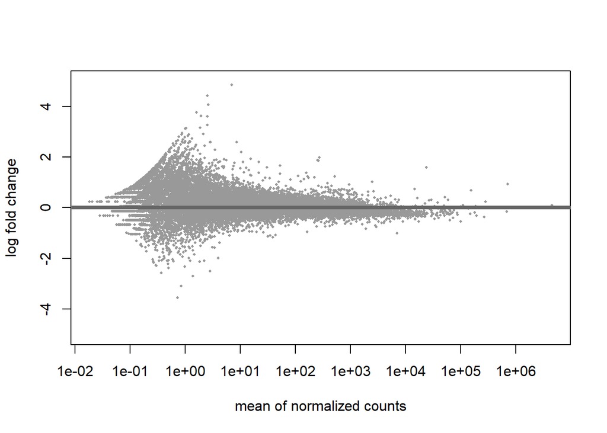

```r
# Create the MA plot
plotMA(res, ylim = c(-5, 5))
```

### Interpretation

The MA plot displays the relationship between the **average normalized gene expression** (x-axis) and the **log2 fold change** between diabetic and control samples (y-axis).

Several observations can be made from this plot:

- Most genes are clustered around a **log2 fold change of 0**, indicating similar expression levels between the diabetic and control groups.
- Genes with **lower average expression** show greater variability in log2 fold change, which is expected because low-count genes generally exhibit higher statistical noise.
- As the average normalized expression increases, the spread of the log2 fold change decreases, indicating that highly expressed genes have more stable expression estimates.
- No genes are highlighted as statistically significant, which is consistent with the DESeq2 analysis showing that **no genes met the selected adjusted p-value threshold (padj < 0.1)** after multiple-testing correction.

Overall, the MA plot suggests that the majority of genes exhibit relatively small expression differences between the diabetic and control samples, and no statistically significant differentially expressed genes were detected under the selected significance criteria.

### Bioinformatics Insight

- **What does an MA plot show?**

  The MA plot compares the **average normalized gene expression (A)** with the **log2 fold change (M)** for every gene. It provides an overview of differential expression across the entire dataset.
- **Why do genes with low expression show greater variability?**

  Lowly expressed genes are supported by fewer sequencing reads, making their fold-change estimates less precise. As a result, they display a wider spread around zero.
- **Why does the plot become narrower as expression increases?**

  Highly expressed genes are measured with more sequencing reads, producing more reliable and stable fold-change estimates. Therefore, the variability decreases as the average expression increases.
- **Why are all points gray in this MA plot?**

  In DESeq2, statistically significant genes are typically highlighted in blue. Since no genes satisfied the selected significance threshold (**adjusted p-value < 0.1**), all genes remain gray.
- **What is the main purpose of an MA plot?**

  The MA plot helps researchers quickly identify genes with large expression changes while simultaneously assessing how expression level influences fold-change variability.

### Key Takeaway

The MA plot demonstrates that most genes have similar expression levels between diabetic and control samples. Greater variability among lowly expressed genes is expected due to increased statistical noise, whereas highly expressed genes produce more stable fold-change estimates. In this dataset, no genes were identified as significantly differentially expressed after multiple-testing correction.

## Principal Component Analysis (PCA)

### Why is this step necessary?

Principal Component Analysis (PCA) is an unsupervised dimensionality reduction technique that summarizes the overall variation in gene expression across all samples.

Instead of examining thousands of genes individually, PCA projects each sample into a two-dimensional space using the principal components that explain the greatest amount of variation in the dataset.

Samples with similar gene expression profiles cluster together, while samples with distinct expression patterns appear farther apart. PCA is commonly used as a quality control step to identify clustering patterns, detect potential outliers, and evaluate whether biological groups separate based on their overall transcriptomic profiles.

```
## using ntop=500 top features by variance
```

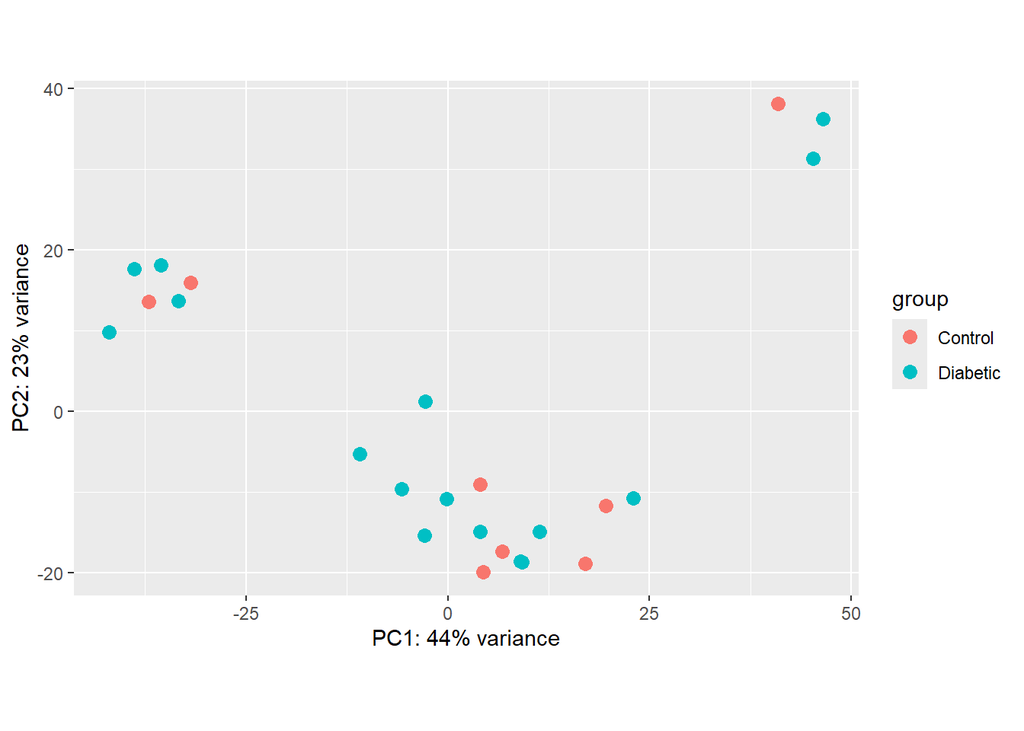

```r
# Apply variance stabilizing transformation
vsd <- vst(dds, blind = FALSE)

# Generate the PCA plot
plotPCA(vsd, intgroup = "Condition")
```

### Interpretation

The PCA plot summarizes the overall variation in gene expression across all 24 pancreatic islet samples. Each point represents an individual sample, and samples are colored according to their experimental group (Control or Diabetic).

The first principal component (**PC1**) explains **44%** of the total variance in the dataset, while the second principal component (**PC2**) explains **23%** of the variance. Together, these two principal components capture approximately **67%** of the overall variation in gene expression.

Several observations can be made from this plot:

- The samples form **multiple clusters**, indicating substantial variability in gene expression across the dataset.
- The diabetic and control samples **partially overlap** within these clusters rather than forming two completely separate groups.
- No obvious outlier samples are observed, suggesting that the dataset is of acceptable quality for downstream differential expression analysis.
- The lack of clear separation between diabetic and control samples is consistent with the DESeq2 results, which did not identify statistically significant differentially expressed genes after multiple-testing correction.

Overall, the PCA plot suggests that biological variation within each group is comparable to the variation between the diabetic and control groups.

### Bioinformatics Insight

- **What is Principal Component Analysis (PCA)?**

  Principal Component Analysis (PCA) is an **unsupervised dimensionality reduction technique** that summarizes thousands of gene expression measurements into a few principal components that explain the largest sources of variation in the dataset.
- **Why is PCA performed before interpreting differential expression results?**

  PCA serves as an important quality control step. It helps identify sample clustering patterns, detect potential outliers, and determine whether biological groups separate based on their overall gene expression profiles.
- **What do PC1 and PC2 represent?**

  Principal components are new variables calculated from the original gene expression data.
  - **PC1** explains the largest proportion of variation in the dataset.
  - **PC2** explains the second largest proportion of variation and is independent of PC1.
- **Does PCA determine whether genes are significantly differentially expressed?**

  No. PCA is an exploratory visualization technique that summarizes overall sample-to-sample variation. Statistical significance is determined separately using differential expression methods such as DESeq2.
- **What can we conclude from this PCA plot?**

  The partial overlap between diabetic and control samples suggests that the overall transcriptomic profiles are relatively similar. This observation agrees with the DESeq2 analysis, which found no genes that satisfied the selected adjusted p-value threshold after multiple-testing correction.

### Key Takeaway

The PCA plot demonstrates that the first two principal components explain approximately **67%** of the total variation in the dataset. Although the samples exhibit several natural clusters, diabetic and control samples are not clearly separated, indicating that overall gene expression patterns are broadly similar between the two groups. This observation is consistent with the differential expression analysis, which identified no statistically significant genes after multiple-testing correction.

## Volcano Plot

### Why is this step necessary?

A volcano plot combines the **magnitude of gene expression change** (log2 fold change) with the **statistical significance** (-log10 adjusted p-value or p-value) for every gene.

This visualization helps identify genes that exhibit both large expression changes and strong statistical evidence for differential expression. Genes with large fold changes and low adjusted p-values typically appear in the upper left and upper right regions of the plot and are considered the strongest candidates for biological investigation.

```r
#First prepare the results
# Convert DESeq2 results to a data frame
res_df <- as.data.frame(res)

# Remove rows containing missing values
res_df <- na.omit(res_df)
```

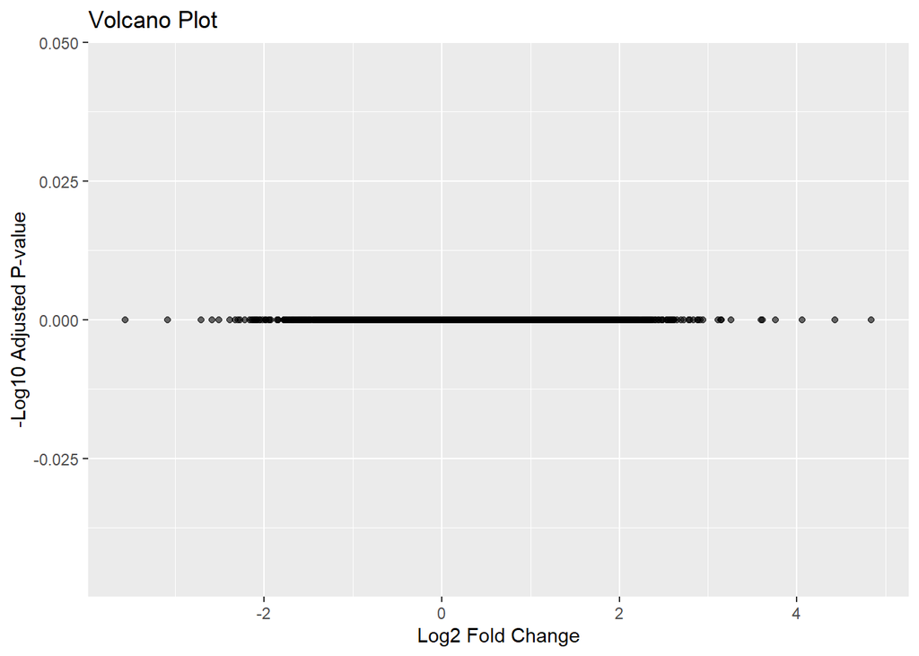

```r
#Now create the volcano plot
library(ggplot2)
ggplot(res_df,
       aes(x = log2FoldChange,
           y = -log10(padj))) +
  geom_point(alpha = 0.6) +
  xlab("Log2 Fold Change") +
  ylab("-Log10 Adjusted P-value") +
  ggtitle("Volcano Plot")
```

### Interpretation

The volcano plot displays the relationship between **log2 fold change** (x-axis) and **statistical significance** represented by the **−log10 adjusted p-value** (y-axis) for all analyzed genes.

Several observations can be made from this plot:

- Most genes are clustered near a **−log10 adjusted p-value of 0**, indicating that their adjusted p-values are close to 1.
- Although some genes exhibit relatively large positive or negative log2 fold changes, these changes are **not statistically significant** after correcting for multiple hypothesis testing.
- No genes appear in the upper left or upper right regions of the plot, where statistically significant differentially expressed genes are typically observed.
- These findings are consistent with the DESeq2 results, which showed that **no genes met the selected significance criteria** after Benjamini–Hochberg multiple-testing correction.

Overall, the volcano plot indicates that this dataset did not provide sufficient statistical evidence to identify significantly differentially expressed genes between diabetic and control pancreatic islet samples.

### Bioinformatics Insight

- **What does a volcano plot show?**

  A volcano plot simultaneously displays the **magnitude of gene expression change (log2 fold change)** and the **statistical significance (adjusted p-value)** for every gene. It allows researchers to quickly identify genes that are both highly differentially expressed and statistically significant.
- **Why is the y-axis represented as −log10(adjusted p-value)?**

  Applying the negative logarithm transforms very small adjusted p-values into larger positive values, making statistically significant genes easier to visualize. Genes with smaller adjusted p-values appear higher on the plot.
- **Why are all points located near the bottom of this volcano plot?**

  Most genes have adjusted p-values close to 1. Because **−log10(1) = 0**, these genes appear near the bottom of the figure, indicating that they are not statistically significant.
- **Why do some genes have large fold changes but still remain at the bottom of the plot?**

  A large fold change alone does not demonstrate statistical significance. Differential expression requires both a meaningful change in expression and sufficient statistical evidence after correcting for multiple hypothesis testing.
- **Why do RNA-seq studies use adjusted p-values instead of raw p-values?**

  Thousands of genes are tested simultaneously in RNA-seq experiments. Adjusted p-values control the false discovery rate (FDR), reducing the likelihood of falsely identifying genes as significant due to multiple comparisons.

### Key Takeaway

The volcano plot demonstrates that none of the analyzed genes satisfied both the biological and statistical criteria for differential expression. Although some genes exhibited noticeable fold changes, these differences were not statistically significant after false discovery rate correction, emphasizing the importance of considering both effect size and adjusted p-value when interpreting RNA-seq results.

Note: In many published RNA-seq studies, volcano plots contain genes highlighted as significantly upregulated or downregulated. In this dataset, all points remain near the bottom of the plot because no genes passed the selected adjusted p-value threshold after multiple-testing correction. Although this may appear unusual, it accurately reflects the statistical results obtained from the DESeq2 analysis

## Dispersion Plot

### Why is this step necessary?

RNA-seq count data exhibit biological variability that must be modeled before differential expression analysis can be performed. DESeq2 estimates the dispersion for each gene, which describes how much the observed counts vary beyond what is expected by random sampling alone.

The dispersion plot visualizes the relationship between the average normalized gene expression and the estimated dispersion values. It also displays the fitted dispersion trend that DESeq2 uses when fitting the negative binomial model.

This plot helps evaluate whether the dispersion estimates have been modeled appropriately across genes with different expression levels.

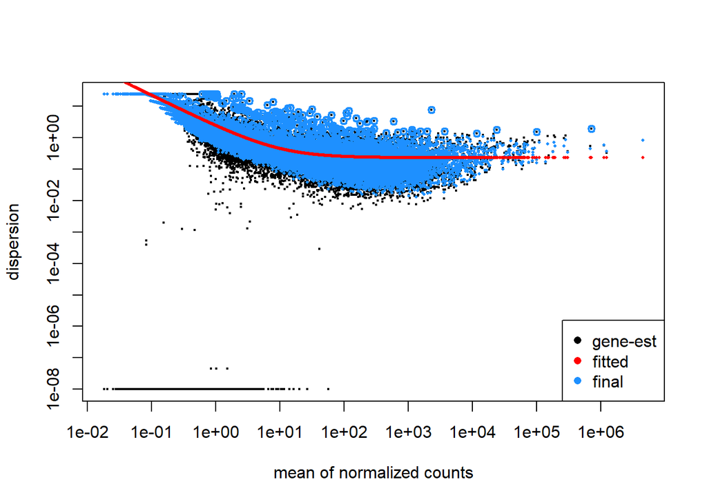

```r
# Plot gene-wise dispersion estimates
plotDispEsts(dds)
```

### Interpretation

The dispersion plot illustrates the relationship between the **mean normalized gene expression** (x-axis) and the **estimated dispersion** (y-axis) for each gene.

The plot contains three types of estimates:

- **Black points (gene-est):** Initial gene-wise dispersion estimates calculated independently for each gene.
- **Red curve (fitted):** The fitted dispersion trend estimated by DESeq2 using all genes.
- **Blue points (final):** Final dispersion estimates after empirical Bayes shrinkage toward the fitted trend.

Several observations can be made from this plot:

- Genes with lower average expression generally exhibit higher dispersion, indicating greater biological and technical variability.
- As the average normalized expression increases, the estimated dispersion decreases and becomes more stable.
- The final dispersion estimates (blue points) closely follow the fitted dispersion trend (red curve), suggesting that DESeq2 successfully modeled the variability across genes.
- No unusual dispersion patterns or widespread outliers are observed, indicating that the dispersion estimates are appropriate for downstream differential expression analysis.

Overall, the dispersion plot demonstrates that the RNA-seq data satisfy the assumptions required for DESeq2’s negative binomial statistical model.

### Bioinformatics Insight

- **What is dispersion?**

  Dispersion measures the variability in gene expression counts across biological samples beyond what would be expected from random sampling alone. DESeq2 models RNA-seq counts using a **negative binomial distribution**, where dispersion represents the extra biological variability.
- **Why is dispersion estimation important?**

  Accurate dispersion estimates are essential because they directly influence the statistical tests used to identify differentially expressed genes. Poor dispersion estimates may lead to false positive or false negative results.
- **Why are there three different estimates?**
  - **Gene-wise estimates (black):** Initial dispersion calculated independently for each gene.
  - **Fitted trend (red):** A smooth curve representing the overall relationship between gene expression and dispersion.
  - **Final estimates (blue):** Shrinkage estimates that combine individual gene information with the fitted trend to improve statistical stability.
- **Why are lowly expressed genes more dispersed?**

  Genes with low expression are supported by fewer sequencing reads, making their estimated expression levels more variable. Consequently, these genes typically exhibit higher dispersion than highly expressed genes.
- **Why does DESeq2 shrink dispersion estimates toward the fitted curve?**

  Shrinkage reduces the influence of noisy gene-specific estimates while preserving genuine biological variation. This improves the accuracy and robustness of differential expression testing.

### Key Takeaway

The dispersion plot confirms that DESeq2 successfully modeled gene-wise variability across the RNA-seq dataset. Lowly expressed genes display greater dispersion, while highly expressed genes show more stable estimates. The close agreement between the final dispersion estimates and the fitted trend indicates that the data are suitable for reliable differential expression analysis. ## Boxplot of Normalized Counts

### Why is this step necessary?

RNA-seq samples often differ in sequencing depth and library size, making direct comparison of raw read counts inappropriate. DESeq2 normalizes the count data by estimating size factors for each sample, allowing expression values to be compared across samples.

A boxplot of the normalized counts provides a visual assessment of whether the normalization procedure has successfully reduced technical differences among samples. After normalization, the distributions of expression values should appear broadly similar across all samples.

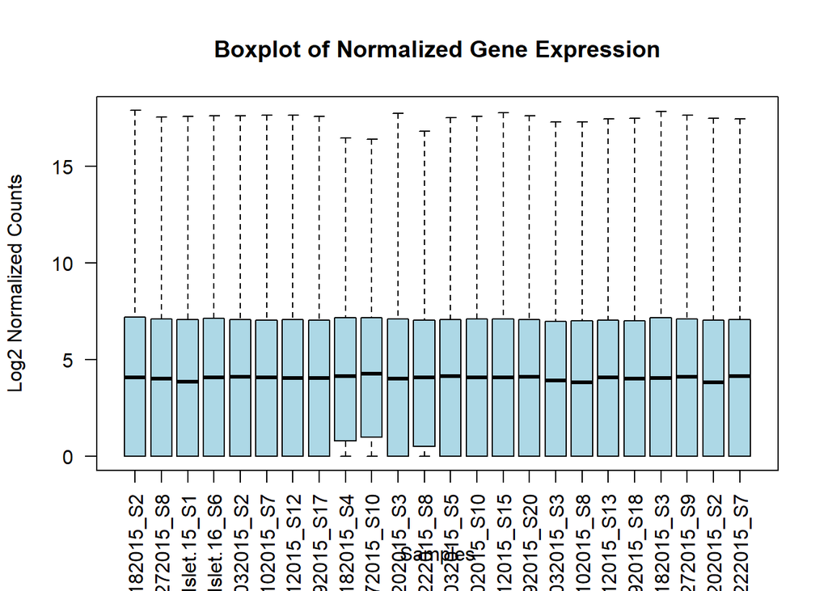

```r
# Extract normalized counts
normalized_counts <- counts(dds, normalized = TRUE)

# Create a boxplot of normalized counts
boxplot(
  log2(normalized_counts + 1),
  las = 2,
  col = "lightblue",
  outline = FALSE,
  xlab = "Samples",
  ylab = "Log2 Normalized Counts",
  main = "Boxplot of Normalized Gene Expression"
)
```

### Interpretation

The boxplot displays the distribution of **log2-transformed normalized gene expression counts** for each RNA-seq sample after DESeq2 normalization.

Overall, the boxplot demonstrates that normalization successfully reduced technical variability, making the samples suitable for downstream differential expression analysis.

### Bioinformatics Insight

- **Why is normalization necessary in RNA-seq?**

  Different RNA-seq samples often have different sequencing depths and library sizes. Without normalization, samples with more sequencing reads would appear to have artificially higher gene expression levels, making direct comparisons unreliable.
- **How does DESeq2 normalize the data?**

  DESeq2 estimates a **size factor** for each sample based on the distribution of gene counts. Raw counts are divided by these size factors, producing normalized counts that are comparable across samples.
- **Why is the boxplot drawn using log2(normalized counts + 1)?**

  Gene expression counts span a very large range. Applying a log2 transformation compresses the scale, reduces the influence of highly expressed genes, and makes differences between samples easier to visualize. Adding 1 prevents undefined values for genes with zero counts.
- **How do we know normalization was successful?**

  Successful normalization is indicated when the boxplots have similar median values, comparable interquartile ranges, and similar overall distributions across samples. Large differences after normalization may suggest remaining technical biases or potential outlier samples.
- **Does normalization remove biological differences?**

  No. Normalization is designed to remove technical variation while preserving true biological differences between samples.

### Key Takeaway

The boxplot confirms that DESeq2 normalization successfully adjusted for differences in sequencing depth and library size across the RNA-seq samples. The similar distributions of normalized gene expression indicate that the data are well prepared for downstream statistical analyses while preserving genuine biological variation.

# Conclusion

This project demonstrated a complete RNA-seq differential expression analysis workflow using the **DESeq2** package in R to investigate gene expression differences between pancreatic islet samples from individuals with **Type 2 Diabetes** and healthy controls.

The analysis included:

- Importing and exploring RNA-seq expression data.
- Preparing sample metadata and the count matrix.
- Creating a DESeq2 dataset.
- Estimating size factors and dispersion values.
- Performing differential expression analysis using the negative binomial model.
- Interpreting statistical results.
- Visualizing the data using MA, PCA, Volcano, Dispersion, and Boxplot visualizations.

The differential expression analysis identified **24,875 genes** with non-zero read counts. However, **no genes met the selected statistical significance threshold** after adjusting for multiple hypothesis testing using the Benjamini–Hochberg false discovery rate (FDR) correction. Although some genes exhibited relatively large fold changes, these differences were not supported by sufficient statistical evidence.

The visualization results were consistent with the statistical analysis:

- The **MA plot** showed that most genes clustered around a log2 fold change of zero.
- The **PCA plot** demonstrated partial overlap between diabetic and control samples, suggesting similar overall gene expression profiles.
- The **Volcano plot** confirmed the absence of statistically significant differentially expressed genes.
- The **Dispersion plot** indicated that DESeq2 successfully modeled biological variability across genes.
- The **Boxplot of normalized counts** demonstrated that normalization effectively reduced technical differences between samples while preserving biological variation.

One limitation of this analysis is that the dataset contained **RSEM expected counts**, which were rounded to integers for educational purposes because DESeq2 is designed to analyze raw integer count data. In addition, the relatively small sample size and biological variability may have reduced the statistical power to detect significant differential expression.

Future work could include analyzing larger RNA-seq datasets, performing pathway enrichment analysis (Gene Ontology or KEGG), annotating significant genes, integrating clinical metadata, and constructing automated RNA-seq workflows using **Nextflow**.

Overall, this project demonstrates a complete and reproducible DESeq2 workflow for RNA-seq differential expression analysis and provides a foundation for more advanced transcriptomic analyses.